# Análisis Predictivo de Diabetes con Random Forest

## 1. Instalación y carga de paquetes

Antes de ejecutar el código, se requiere la instalación y la carga de ciertos paquetes dentro de R (sólo la primera vez). Esto se hace directamente en la consola. Los paquetes que vamos a usar son los siguientes: “caret” “ggplot2” “mlbench” “OptimalCutpoints” “pROC” “randomForest” Estos paquetes permiten la manipulación de datos, el entrenamiento de modelos y la generación de visualizaciones.

Para más información acerca de los paquetes consultar los siguientes enlaces:  
“caret”: https://cran.r-project.org/web/packages/caret/index.html “ggplot2”: https://cran.r-project.org/web/packages/ggplot2/index.html “mlbench”: https://cran.r-project.org/web/packages/mlbench/index.html “OptimalCutpoints”: https://cran.r-project.org/web/packages/OptimalCutpoints/index.html “pROC”: https://cran.r-project.org/web/packages/pROC/index.html “randomForest”: https://cran.r-project.org/web/packages/randomForest/index.html

```r
# SECCIÓN 1: Instalar y/o cargar liberías ---
# Función para instalar y cargar paquetes si no están instalados
install_if_missing <- function(pkg) {
  if (!requireNamespace(pkg, quietly = TRUE)) {
    install.packages(pkg, dependencies = TRUE)
  }
  library(pkg, character.only = TRUE)
}
# Lista de paquetes necesarios
paquetes <- c("caret", "mlbench", "pROC", "randomForest", "OptimalCutpoints", "ggplot2")
# Aplicar la función a cada paquete
sapply(paquetes, install_if_missing)
```

```
## S'està carregant el paquet requerit: ggplot2
```

```
## S'està carregant el paquet requerit: lattice
```

```
##
## S'està adjuntant el paquet: 'pROC'
```

```
##
## S'està adjuntant el paquet: 'randomForest'
```

[output not shown]

## 2. Carga del conjunto de datos

Se pueden importar datos desde diferentes orígenes, como hojas de cálculo en Excel ubicadas en un directorio específico, bases de datos SQL u otros formatos con los que R puede conectarse. En este caso, se utiliza el conjunto de datos “PimaIndiansDiabetes” que contiene información sobre pacientes y su estado de diabetes.

```r
# SECCIÓN 2: Cargar dataset ---
data(PimaIndiansDiabetes)
df <- PimaIndiansDiabetes
```

## 3. Definición de los parámetros generales

Se define la variable de salida, en este caso “diabetes” (OUTPUT), y se establecen las etiquetas para los valores positivos (LEVEL1) y negativos (LEVEL0). Esto es fundamental para garantizar que los análisis sean coherentes y comparables. En la sección 3 del código se puede modificar por el nombre de variable y niveles por los que se deseen personalizar siempre y cuando coincidan con los datos importados.

```r
# SECCIÓN 3: Definir parámetros generales ---
OUTPUT <- "diabetes"  # Variable de salida (ajustar si cambia el dataset)
LEVEL1 <- "pos"       # Clase positiva (evento de interés)
LEVEL0 <- "neg"       # Clase negativa
```

## 4. Preparación de datos

Se convierte la variable de salida en un factor para que R la interprete correctamente en los modelos. Luego, se divide el dataset en conjunto de entrenamiento (80% de los datos) y conjunto de prueba (20%). Esta separación es importante para evaluar el rendimiento del modelo en datos no vistos previamente.

```r
# SECCIÓN 4: Preparación de datos ---
# Convertir la variable de salida en factor con los niveles definidos
df[[OUTPUT]] <- factor(df[[OUTPUT]], levels = c(LEVEL0, LEVEL1))

# Dividir en conjunto de entrenamiento y prueba
set.seed(123)
trainIndex <- createDataPartition(df[[OUTPUT]], p = 0.8, list = FALSE)
trainData <- df[trainIndex, ]
testData <- df[-trainIndex, ]
```

## 5. Entrenamiento del modelo y análisis de los resultados

Se entrena un modelo de Random Forest utilizando validación cruzada de 5 pliegues (5-fold cross-validation) para garantizar robustez en los resultados. El modelo se entrena con la variable “diabetes” como salida y el resto de las variables como predictores. El modelo y sus características son personalizables en la sección 5 del código. Se generan predicciones para el conjunto de prueba, estableciendo un umbral de 0.5 para clasificar como “positivo” o “negativo”. Posteriormente, se calcula la matriz de confusión y las métricas de desempeño del modelo: AUC, Acierto, F1-Score, Sensibilidad, Especificidad, Valor Predictivo Positivo y Valor Predictivo Negativo.

```r
# SECCIÓN 5: Entrenamiento del modelo ---
# Definir control de entrenamiento con validación cruzada
train_control <- trainControl(method = "cv", number = 5, classProbs = TRUE, summaryFunction = twoClassSummary)

# Ajustar modelo (Random Forest)
tune_grid <- expand.grid(mtry = c(2, 3, 4, 5))  # Número de variables en cada división

modelo <- train(as.formula(paste(OUTPUT, "~ .")), data = trainData, method = "rf",
                trControl = train_control, metric = "ROC",
                tuneGrid = tune_grid,
                ntree = 1000)  # Ajusta el número de árboles

# Predicciones en test
pred <- predict(modelo, testData, type = "prob")

# Convertir en factores según umbral 0.5
pred_class <- factor(ifelse(pred[[LEVEL1]] > 0.5, LEVEL1, LEVEL0), levels = c(LEVEL0, LEVEL1))

# Matriz de confusión
conf_mat <- confusionMatrix(pred_class, testData[[OUTPUT]],
                            positive = LEVEL1)

# Extraer las métricas
metrics_total <- data.frame(
  F1Score = conf_mat$byClass["F1"],
  Sens = conf_mat$byClass["Sensitivity"],
  Spec = conf_mat$byClass["Specificity"],
  PPV = conf_mat$byClass["Pos Pred Value"],
  NPV = conf_mat$byClass["Neg Pred Value"]
)
```

## 6. Evaluación del modelo mediante curva ROC

Se construye la curva ROC, la cual representa la relación entre la sensibilidad y 1 - especificidad del modelo. El área bajo la curva (AUC) se calcula para evaluar la capacidad discriminativa del modelo: valores cercanos a 1 indican un buen desempeño. Se extraen los datos de la curva y se visualizan utilizando “ggplot2”. En la gráfica, la curva ROC se compara con la línea diagonal de referencia (modelo aleatorio), permitiendo evaluar visualmente la calidad del modelo.

```r
# SECCIÓN 6: Análisis de los resultados ---
# Calcular curva ROC y AUC
roc_curve <- roc(testData[[OUTPUT]], pred[[LEVEL1]])  # Usar la probabilidad de la clase positiva
AUC_value <- auc(roc_curve)
print(AUC_value)
```

```
## Area under the curve: 0.875
```

```r
# Añadir AUC al data frame de métricas
metrics_total$AUC <- AUC_value
# Extraer los datos de la curva ROC para graficar
roc_data <- data.frame(
  Sensitivity = roc_curve$sensitivities,
  Specificity = 1 - roc_curve$specificities
)
# Crear el gráfico con ggplot2
curvaROC <- ggplot(roc_data, aes(x = Specificity, y = Sensitivity)) +
  geom_line(color = "#008CBD", linewidth = 1.2) +  # Línea de la curva ROC
  geom_abline(slope = 1, intercept = 0, linetype = "dashed", color = "gray") +  # Línea de referencia (diagonal)
  labs(
    title = "Curva ROC",
    subtitle = paste("AUC =", round(AUC_value, 3)),
    x = "1 - Especificidad",
    y = "Sensibilidad"
  ) +
  scale_x_continuous(expand = c(0, 0), limits = c(0, 1)) +  # Asegurar que el eje x comience en 0
  scale_y_continuous(expand = c(0, 0), limits = c(0, 1.1)) +  # Asegurar que el eje y comience en 0
  theme_bw(base_size = 14) +  # Usar tema con bordes
  theme(
    plot.title = element_text(hjust = 0.5, size = 16, face = "bold"),  # Centrar título
    plot.subtitle = element_text(hjust = 0.5, size = 14, face = "italic")  # Centrar subtítulo
  )
```

## 7. Determinación del umbral óptimo

Se utiliza el método de Youden para determinar el umbral óptimo de clasificación basado en la sensibilidad y especificidad. Esto permite encontrar el punto de corte que maximiza la discriminación entre las clases positivas y negativas.

```r
# Añadir las probabilidades al dataset de test con el nombre correcto
testData$predicho <- pred[[LEVEL1]]
# Calcular el umbral óptimo basado en Sensibilidad y Especificidad (Youden)
opt_cut <- optimal.cutpoints(X = "predicho", status = OUTPUT,
                             tag.healthy = LEVEL0, tag.disease = LEVEL1,
                             methods = "Youden", data = testData)
```

## 8. Importancia de variables

Se evalúa la importancia de cada variable predictora en la toma de decisiones del modelo. Esto se visualiza con una gráfica de importancia de variables. Permite identificar cuáles son los factores más relevantes para predecir la variable de interés.

```r
# Importancia de variables con caret
var_imp <- varImp(modelo)
```

## 9. Visualización de resultados

Los resultados principales que se generan incluyen: - Matriz de confusión: Resume el desempeño del modelo. - Curva ROC: Permite visualizar la capacidad discriminativa. - Métricas de evaluación: Presentadas en formato tabular. - Umbral óptimo: Indica el mejor punto de corte según el criterio de Youden. - Gráfico de importancia de variables: Muestra los predictores más influyentes.

```r
cat("\014")  # Simula Ctrl + L para limpiar la consola
```

```r
# VISUALIZAR RESULTADOS
print(conf_mat)
```

```
## Confusion Matrix and Statistics
##
##           Reference
## Prediction neg pos
##        neg  89  19
##        pos  11  34
##
##                Accuracy : 0.8039
##                  95% CI : (0.7321, 0.8636)
##     No Information Rate : 0.6536
##     P-Value [Acc > NIR] : 3.3e-05
##
##                   Kappa : 0.5511
##
##  Mcnemar's Test P-Value : 0.2012
##
##             Sensitivity : 0.6415
##             Specificity : 0.8900
##          Pos Pred Value : 0.7556
##          Neg Pred Value : 0.8241
##              Prevalence : 0.3464
##          Detection Rate : 0.2222
##    Detection Prevalence : 0.2941
##       Balanced Accuracy : 0.7658
##
##        'Positive' Class : pos
##
```

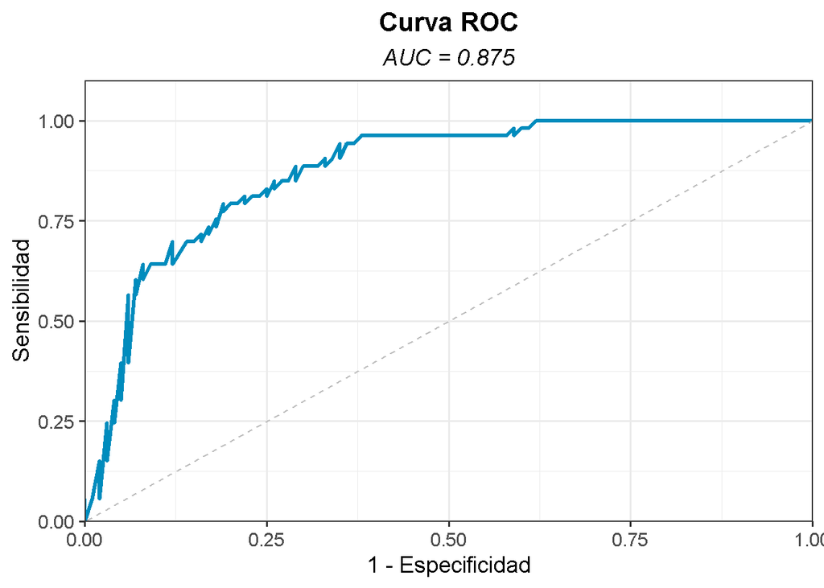

```r
# Mostrar el gráfico
print(curvaROC)
```

```r
# Mostrar métricas finales
print(metrics_total)
```

```
##      F1Score      Sens Spec       PPV       NPV   AUC
## F1 0.6938776 0.6415094 0.89 0.7555556 0.8240741 0.875
```

```r
# Mostrar resultados cut-off points
summary(opt_cut)
```

```
##
## Call:
## optimal.cutpoints.default(X = "predicho", status = OUTPUT, tag.healthy = LEVEL0,
##     methods = "Youden", data = testData, tag.disease = LEVEL1)
##
## Area under the ROC curve (AUC):  0.875 (0.82, 0.93)
##
## CRITERION: Youden
## Number of optimal cutoffs: 1
##
##                     Estimate
## cutoff             0.3890000
## Se                 0.7924528
## Sp                 0.8100000
## PPV                0.6885246
## NPV                0.8804348
## DLR.Positive       4.1708044
## DLR.Negative       0.2562311
## FP                19.0000000
## FN                11.0000000
## Optimal criterion  0.6024528
```

```r
# Importancia de variables
print(var_imp)
```

```
## rf variable importance
##
##           Overall
## glucose  100.0000
## mass      45.6508
## age       30.2522
## pedigree  29.3456
## pressure  13.3647
## pregnant   5.9140
## triceps    0.2319
## insulin    0.0000
```

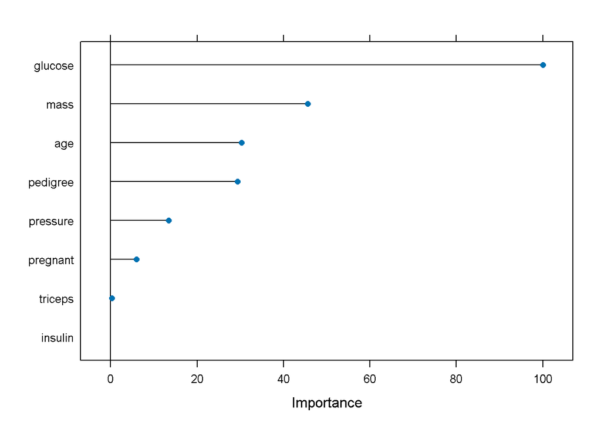

```r
plot(var_imp)
```